# STAT2003 Analytics for Experimental and Simulated Data

ASSIGNMENT 2

5 pm, 6<sup>th</sup> November 2018

```r
library(lhs)
library(DiceDesign)
library(FrF2)
library(recoder)
library(leaps)
library(analogue)
library(rriskDistributions)
require(MASS)
require(AlgDesign)
require(SPOT)
```

# Introduction

Your task is to develop a meta model (proxy model) for the water flow rate (WFR) through a borehole $y_{0} (m^{3}/yr)$. The WFR is determined by eight input variables as described below

| Input Variable | Variable Description | Lower Limit | Upper Limit | Code |
| --- | --- | --- | --- | --- |
| $r_{w}$ | Radius of borehole (m) | 0.05 | 0.15 | $x_{1}$ |
| $r$ | Radius of influence (m) | 100 | 50000 | $x_{2}$ |
| $T_{u}$ | Transitivity of upper aquifer ($m^{2}/yr$) | 63070 | 115600 | $x_{3}$ |
| $H_{u}$ | Potentiometric head of upper aquifer ($m^{2}/yr$) | 900 | 1110 | $x_{4}$ |
| $T_{l}$ | Transmissivity of lower aquifer ($m^{2}/yr$) | 63.1 | 116 | $x_{5}$ |
| $H_{l}$ | Potentiometric head of lower aquifer (m) | 700 | 820 | $x_{6}$ |
| $L$ | Length of borehole (m) | 1120 | 1680 | $x_{7}$ |
| $K_{w}$ | Hydraulic conductivity of borehole ($m/yr$) | 9855 | 12045 | $x_{8}$ |

For any given settings of input variables, value of the water flow rate can be computed by function *WaterFlowRateInBorehole* given below

```r
WaterFlowRateInBorehole<-function(x){
(2*(22/7)*x[3]*(x[4]-x[6]))/((log(x[2]/x[1]))*(1+((2*x[7]*x[3])/((log(x[2]/x[1]))*(x[1]^2)*x[8]))+(x[3]/x[5]))) + rnorm(1,10,20)
}

#xmid=c(0.1,25000,89335,5055,89.5,760,1400,10950)
set.seed(13)
pbBore <- pb(12, 8, randomize = FALSE, seed = 13) #Creates Plackett Burmann 12 runs
#Converts factors into numeric values for each column
A <- as.numeric(pbBore$A)
B <- as.numeric(pbBore$B)
C <- as.numeric(pbBore$C)
D <- as.numeric(pbBore$D)
E <- as.numeric(pbBore$E)
F1 <- as.numeric(pbBore$F)
G <- as.numeric(pbBore$G)
H <- as.numeric(pbBore$H)

#According to whether the value is 2 or 1, convert it into the upper and lower limit accordingly
rBore <- recoder(A, '== 2: 0.15; == 1: 0.05')
rInf <- recoder(B, '== 2: 50000; == 1: 100')
trans <- recoder(C, '== 2: 115600; == 1: 63070')
potent <- recoder(D, '== 2: 1100; == 1: 900')
transmis <- recoder(E, '== 2: 116; == 1: 63.1')
potent2 <- recoder(F1, '== 2: 820; == 1: 700')
lenBore <- recoder(G, '== 2: 1680; == 1: 1120')
hydra <- recoder(H, '== 2: 12045; == 1: 9855')


mtxPB <- matrix(c(rBore,rInf,trans, potent, transmis, potent2, lenBore, hydra), nrow = 12, ncol = 8) #Adds all results (upper and lower limit) into a matrix
outMtx <- matrix(nrow = 12, ncol = 1) #Initiates a matrix to store results
mtxPB
```

```
##       [,1]  [,2]   [,3] [,4]  [,5] [,6] [,7]  [,8]
##  [1,] 0.15 50000  63070 1100 116.0  820 1120  9855
##  [2,] 0.05 50000 115600  900 116.0  820 1680  9855
##  [3,] 0.15   100 115600 1100  63.1  820 1680 12045
##  [4,] 0.05 50000  63070 1100 116.0  700 1680 12045
##  [5,] 0.05   100 115600  900 116.0  820 1120 12045
##  [6,] 0.05   100  63070 1100  63.1  820 1680  9855
##  [7,] 0.15   100  63070  900 116.0  700 1680 12045
##  [8,] 0.15 50000  63070  900  63.1  820 1120 12045
##  [9,] 0.15 50000 115600  900  63.1  700 1680  9855
## [10,] 0.05 50000 115600 1100  63.1  700 1120 12045
## [11,] 0.15   100 115600 1100 116.0  700 1120  9855
## [12,] 0.05   100  63070  900  63.1  700 1120  9855
```

```r
#Generates results of upper and lower limit matrix and adds it to the results matrix
for (i in seq(1,12)){
  outMtx[i,1] <- WaterFlowRateInBorehole(mtxPB[i,])
}
outMtx
```

```
##             [,1]
##  [1,] 193.435074
##  [2,]   8.078586
##  [3,] 186.291376
##  [4,]  36.255496
##  [5,]  39.604517
##  [6,]  31.204480
##  [7,] 135.532142
##  [8,]  74.123560
##  [9,]  84.565843
## [10,]  65.803385
## [11,] 235.642365
## [12,]  33.046273
```

```r
#WaterFlowRateInBorehole(xmid)
```

```r
reformatDF <- data.frame(mtxPB)
reformatDF <- cbind(reformatDF,outMtx)
reformatDF #matrix containing results and min/max ranges
```

```
##      X1    X2     X3   X4    X5  X6   X7    X8     outMtx
## 1  0.15 50000  63070 1100 116.0 820 1120  9855 193.435074
## 2  0.05 50000 115600  900 116.0 820 1680  9855   8.078586
## 3  0.15   100 115600 1100  63.1 820 1680 12045 186.291376
## 4  0.05 50000  63070 1100 116.0 700 1680 12045  36.255496
## 5  0.05   100 115600  900 116.0 820 1120 12045  39.604517
## 6  0.05   100  63070 1100  63.1 820 1680  9855  31.204480
## 7  0.15   100  63070  900 116.0 700 1680 12045 135.532142
## 8  0.15 50000  63070  900  63.1 820 1120 12045  74.123560
## 9  0.15 50000 115600  900  63.1 700 1680  9855  84.565843
## 10 0.05 50000 115600 1100  63.1 700 1120 12045  65.803385
## 11 0.15   100 115600 1100 116.0 700 1120  9855 235.642365
## 12 0.05   100  63070  900  63.1 700 1120  9855  33.046273
```

```r
AllSubsets <- regsubsets(outMtx~., data = reformatDF, nvmax = 11, nbest = 1)
AllSubSum <- summary(AllSubsets)
AllSubSum$outmat
```

```
##          X1  X2  X3  X4  X5  X6  X7  X8
## 1  ( 1 ) "*" " " " " " " " " " " " " " "
## 2  ( 1 ) "*" " " " " "*" " " " " " " " "
## 3  ( 1 ) "*" "*" " " "*" " " " " " " " "
## 4  ( 1 ) "*" "*" " " "*" "*" " " " " " "
## 5  ( 1 ) "*" "*" " " "*" "*" " " "*" " "
## 6  ( 1 ) "*" "*" "*" "*" "*" " " "*" " "
## 7  ( 1 ) "*" "*" "*" "*" "*" "*" "*" " "
## 8  ( 1 ) "*" "*" "*" "*" "*" "*" "*" "*"
```

```r
summary(AllSubSum)
```

```
##        Length Class      Mode
## which  72     -none-     logical
## rsq     8     -none-     numeric
## rss     8     -none-     numeric
## adjr2   8     -none-     numeric
## cp      8     -none-     numeric
## bic     8     -none-     numeric
## outmat 64     -none-     character
## obj    28     regsubsets list
```

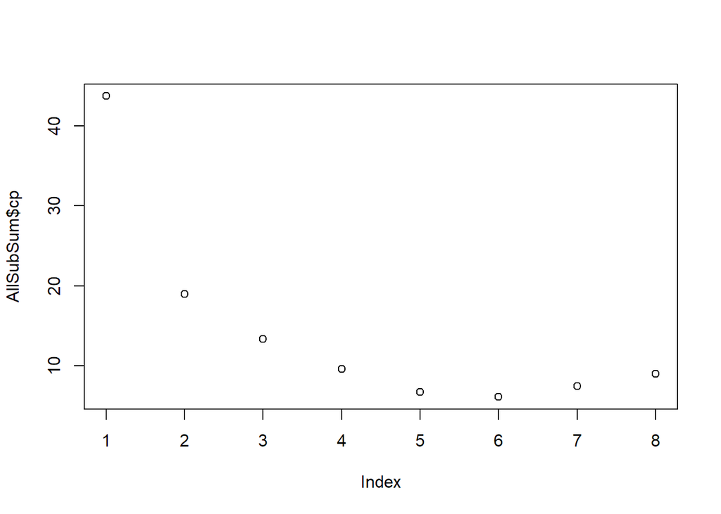

```r
plot(AllSubSum$cp)
```

```r
boreAOV <- aov(outMtx~., data = reformatDF)
anova(boreAOV)
```

```
## Analysis of Variance Table
##
## Response: outMtx
##           Df Sum Sq Mean Sq F value   Pr(>F)
## X1         1  40321   40321 92.7320 0.002377 **
## X2         1   3302    3302  7.5941 0.070403 .
## X3         1   1129    1129  2.5962 0.205508
## X4         1  11636   11636 26.7618 0.014017 *
## X5         1   2509    2509  5.7700 0.095694 .
## X6         1    281     281  0.6471 0.479988
## X7         1   2126    2126  4.8896 0.113970
## X8         1    195     195  0.4483 0.551086
## Residuals  3   1304     435
## ---
## Signif. codes:  0 '***' 0.001 '**' 0.01 '*' 0.05 '.' 0.1 ' ' 1
```

```r
AllSubSum$outmat
```

```
##          X1  X2  X3  X4  X5  X6  X7  X8
## 1  ( 1 ) "*" " " " " " " " " " " " " " "
## 2  ( 1 ) "*" " " " " "*" " " " " " " " "
## 3  ( 1 ) "*" "*" " " "*" " " " " " " " "
## 4  ( 1 ) "*" "*" " " "*" "*" " " " " " "
## 5  ( 1 ) "*" "*" " " "*" "*" " " "*" " "
## 6  ( 1 ) "*" "*" "*" "*" "*" " " "*" " "
## 7  ( 1 ) "*" "*" "*" "*" "*" "*" "*" " "
## 8  ( 1 ) "*" "*" "*" "*" "*" "*" "*" "*"
```

```r
# creating our model using stewpise selection
SimplestModel <- lm(outMtx ~ 1, data = reformatDF)
FullModel <- lm(outMtx ~., data = reformatDF)
Forward <- step(SimplestModel, scope = formula(FullModel), direction = 'forward')
```

```
## Start:  AIC=104.75
## outMtx ~ 1
##
##        Df Sum of Sq   RSS     AIC
## + X1    1     40321 22483  94.427
## + X4    1     11636 51168 104.296
## <none>              62804 104.754
## + X2    1      3302 59502 106.106
## + X5    1      2509 60296 106.265
## + X7    1      2126 60678 106.341
## + X3    1      1129 61676 106.537
## + X6    1       281 62523 106.701
## + X8    1       195 62610 106.717
##
## Step:  AIC=94.43
## outMtx ~ X1
##
##        Df Sum of Sq   RSS    AIC
## + X4    1   11636.5 10847 87.680
## <none>              22483 94.427
## + X2    1    3302.0 19181 94.521
## + X5    1    2508.9 19974 95.007
## + X7    1    2126.1 20357 95.235
## + X3    1    1128.9 21354 95.809
## + X6    1     281.4 22202 96.276
## + X8    1     194.9 22288 96.323
##
## Step:  AIC=87.68
## outMtx ~ X1 + X4
##
##        Df Sum of Sq     RSS    AIC
## + X2    1    3302.0  7544.6 85.324
## + X5    1    2508.9  8337.7 86.524
## + X7    1    2126.1  8720.6 87.062
## <none>              10846.6 87.680
## + X3    1    1128.9  9717.8 88.362
## + X6    1     281.4 10565.2 89.365
## + X8    1     194.9 10651.7 89.463
##
## Step:  AIC=85.32
```

[output cut: 28 more lines]

```
##
## Step:  AIC=74
## outMtx ~ X1 + X4 + X2 + X5 + X7 + X3
##
##        Df Sum of Sq    RSS    AIC
## + X6    1    281.38 1499.4 73.935
## <none>              1780.7 73.998
## + X8    1    194.91 1585.8 74.607
##
## Step:  AIC=73.93
## outMtx ~ X1 + X4 + X2 + X5 + X7 + X3 + X6
##
##        Df Sum of Sq    RSS    AIC
## <none>              1499.4 73.935
## + X8    1    194.91 1304.5 74.264
```

```r
summary(Forward)
```

```
##
## Call:
## lm.default(formula = outMtx ~ X1 + X4 + X2 + X5 + X7 + X3 + X6,
##     data = reformatDF)
##
## Residuals:
##       1       2       3       4       5       6       7       8       9
##  14.056  14.136   9.878 -10.254 -14.136  -9.878   2.194 -14.056  -6.076
##      10      11      12
##   2.194  -5.996  17.938
##
## Coefficients:
##               Estimate Std. Error t value Pr(>|t|)
## (Intercept) -2.711e+02  9.911e+01  -2.735 0.052158 .
## X1           1.159e+03  1.118e+02  10.372 0.000488 ***
## X4           3.114e-01  5.589e-02   5.572 0.005085 **
## X2          -6.649e-04  2.240e-04  -2.968 0.041224 *
## X5           5.467e-01  2.113e-01   2.587 0.060867 .
## X7          -4.754e-02  1.996e-02  -2.382 0.075858 .
## X3           3.693e-04  2.128e-04   1.735 0.157684
## X6          -8.071e-02  9.315e-02  -0.866 0.435144
## ---
## Signif. codes:  0 '***' 0.001 '**' 0.01 '*' 0.05 '.' 0.1 ' ' 1
##
## Residual standard error: 19.36 on 4 degrees of freedom
## Multiple R-squared:  0.9761, Adjusted R-squared:  0.9343
## F-statistic: 23.36 on 7 and 4 DF,  p-value: 0.004312
```

```r
print("Forward")
```

```
## [1] "Forward"
```

```r
coef(Forward)
```

```
##   (Intercept)            X1            X4            X2            X5
## -2.711020e+02  1.159329e+03  3.114010e-01 -6.648604e-04  5.466706e-01
##            X7            X3            X6
## -4.753787e-02  3.692780e-04 -8.070543e-02
```

```r
Backward <- step(FullModel, direction = 'backward')
```

```
## Start:  AIC=74.26
## outMtx ~ X1 + X2 + X3 + X4 + X5 + X6 + X7 + X8
##
##        Df Sum of Sq   RSS     AIC
## - X8    1       195  1499  73.935
## <none>               1304  74.264
## - X6    1       281  1586  74.607
## - X3    1      1129  2433  79.745
## - X7    1      2126  3431  83.867
## - X5    1      2509  3813  85.136
## - X2    1      3302  4606  87.404
## - X4    1     11636 12941  99.799
## - X1    1     40321 41626 113.819
##
## Step:  AIC=73.93
## outMtx ~ X1 + X2 + X3 + X4 + X5 + X6 + X7
##
##        Df Sum of Sq   RSS     AIC
## <none>               1499  73.935
## - X6    1       281  1781  73.998
## - X3    1      1129  2628  78.670
## - X7    1      2126  3625  82.530
## - X5    1      2509  4008  83.734
## - X2    1      3302  4801  85.901
## - X4    1     11636 13136  97.978
## - X1    1     40321 41821 111.875
```

```r
print("Backward")
```

```
## [1] "Backward"
```

```r
coef(Backward)
```

```
##   (Intercept)            X1            X2            X3            X4
## -2.711020e+02  1.159329e+03 -6.648604e-04  3.692780e-04  3.114010e-01
##            X5            X6            X7
##  5.466706e-01 -8.070543e-02 -4.753787e-02
```

```r
Step <- step(SimplestModel, scope = formula(FullModel))
```

```
## Start:  AIC=104.75
## outMtx ~ 1
##
##        Df Sum of Sq   RSS     AIC
## + X1    1     40321 22483  94.427
## + X4    1     11636 51168 104.296
## <none>              62804 104.754
## + X2    1      3302 59502 106.106
## + X5    1      2509 60296 106.265
## + X7    1      2126 60678 106.341
## + X3    1      1129 61676 106.537
## + X6    1       281 62523 106.701
## + X8    1       195 62610 106.717
##
## Step:  AIC=94.43
## outMtx ~ X1
##
##        Df Sum of Sq   RSS     AIC
## + X4    1     11636 10847  87.680
## <none>              22483  94.427
## + X2    1      3302 19181  94.521
## + X5    1      2509 19974  95.007
## + X7    1      2126 20357  95.235
## + X3    1      1129 21354  95.809
## + X6    1       281 22202  96.276
## + X8    1       195 22288  96.323
## - X1    1     40321 62804 104.754
##
## Step:  AIC=87.68
## outMtx ~ X1 + X4
##
##        Df Sum of Sq   RSS     AIC
## + X2    1      3302  7545  85.324
## + X5    1      2509  8338  86.524
## + X7    1      2126  8721  87.062
## <none>              10847  87.680
## + X3    1      1129  9718  88.362
## + X6    1       281 10565  89.365
## + X8    1       195 10652  89.463
## - X4    1     11636 22483  94.427
```

[output cut: 56 more lines]

```
## - X1    1     40321 42102 109.955
##
## Step:  AIC=73.93
## outMtx ~ X1 + X4 + X2 + X5 + X7 + X3 + X6
##
##        Df Sum of Sq   RSS     AIC
## <none>               1499  73.935
## - X6    1       281  1781  73.998
## + X8    1       195  1304  74.264
## - X3    1      1129  2628  78.670
## - X7    1      2126  3625  82.530
## - X5    1      2509  4008  83.734
## - X2    1      3302  4801  85.901
## - X4    1     11636 13136  97.978
## - X1    1     40321 41821 111.875
```

```r
print("Step")
```

```
## [1] "Step"
```

```r
coef(Step)
```

```
##   (Intercept)            X1            X4            X2            X5
## -2.711020e+02  1.159329e+03  3.114010e-01 -6.648604e-04  5.466706e-01
##            X7            X3            X6
## -4.753787e-02  3.692780e-04 -8.070543e-02
```

```r
set.seed(13)
xMatrix <- gen.factorial(levels = 3, nVars = 4, varNames = c("X1","X2","X4","X5"))

xd <- optFederov(~X1+X2+X4+X5, data = xMatrix, 50)
#Cm <- mean()
X1_m <- mean(range(0.05, 0.15))
X2_m <- mean(range(100, 50000))
X3_m <- mean(range(63070, 115600))
X4_m <- mean(range(900, 1110))
X5_m <- mean(range(63.1, 116))
X6_m <- mean(range(700, 820))
X7_m <- mean(range(1120, 1680))
X8_m <- mean(range(9855, 12045))

X1 <- xd$design$X1
X2 <- xd$design$X2
X4 <- xd$design$X4
X5 <- xd$design$X5

X1 <- recoder(X1, '== 1: 0.15; == -1: 0.05; == 0: X1_m')
X2 <- recoder(X2, '== 1: 100; == -1: 50000; == 0: X2_m')
X4 <- recoder(X4, '== 1: 900; == -1: 1110; == 0: X4_m')
X5 <- recoder(X5, '== 1: 63.1; == -1: 116; == 0: X5_m')

num_rows <- nrow(xd$design)

X3 <- rep(X3_m, num_rows)
X6 <- rep(X6_m, num_rows)
X7 <- rep(X7_m, num_rows)
X8 <- rep(X8_m, num_rows)

mtxDopt <- matrix(c(X1,X2,X3,X4,X5,X6,X7,X8), ncol = 8)
mtxDopt
```

```
##       [,1]  [,2]  [,3] [,4]   [,5] [,6] [,7]  [,8]
##  [1,] 0.05 50000 89335 1110 116.00  760 1400 10950
##  [2,] 0.10 50000 89335 1110 116.00  760 1400 10950
##  [3,] 0.15 50000 89335 1110 116.00  760 1400 10950
##  [4,] 0.05 25050 89335 1110 116.00  760 1400 10950
##  [5,] 0.15 25050 89335 1110 116.00  760 1400 10950
##  [6,] 0.05   100 89335 1110 116.00  760 1400 10950
##  [7,] 0.10   100 89335 1110 116.00  760 1400 10950
##  [8,] 0.15   100 89335 1110 116.00  760 1400 10950
##  [9,] 0.05 50000 89335 1005 116.00  760 1400 10950
## [10,] 0.15 50000 89335 1005 116.00  760 1400 10950
## [11,] 0.05   100 89335 1005 116.00  760 1400 10950
## [12,] 0.15   100 89335 1005 116.00  760 1400 10950
## [13,] 0.05 50000 89335  900 116.00  760 1400 10950
## [14,] 0.10 50000 89335  900 116.00  760 1400 10950
```

[output cut: 36 more lines]

```r
test_mtx <- data.frame(cbind(runif(50, 0.05, 0.15),
                      runif(50, 100, 50000),
                      runif(50, 63070, 115600),
                      runif(50, 900, 1110),
                      runif(50, 63.1, 116),
                      runif(50, 700, 820),
                      runif(50, 1120, 1680),
                      runif(50, 9855, 12045),
                     ncol = 8,
                     nrow = 50))
```

```r
mtxRes <- matrix(nrow = num_rows, ncol = 1)
for (i in seq(1,50)){
  mtxRes[i,1] <- WaterFlowRateInBorehole(mtxDopt[i,])
}

mtx_opt <- cbind(mtxDopt, mtxRes)
eg <- as.data.frame(mtx_opt)
eg
```

```
##      V1    V2    V3   V4     V5  V6   V7    V8          V9
## 1  0.05 50000 89335 1110 116.00 760 1400 10950  35.7188582
## 2  0.10 50000 89335 1110 116.00 760 1400 10950  98.9716708
## 3  0.15 50000 89335 1110 116.00 760 1400 10950 214.3965683
## 4  0.05 25050 89335 1110 116.00 760 1400 10950  12.4251768
## 5  0.15 25050 89335 1110 116.00 760 1400 10950 189.9934486
## 6  0.05   100 89335 1110 116.00 760 1400 10950  31.4740592
## 7  0.10   100 89335 1110 116.00 760 1400 10950  94.9539322
## 8  0.15   100 89335 1110 116.00 760 1400 10950 203.9537535
## 9  0.05 50000 89335 1005 116.00 760 1400 10950  17.2433049
## 10 0.15 50000 89335 1005 116.00 760 1400 10950 152.1240618
## 11 0.05   100 89335 1005 116.00 760 1400 10950  22.1262529
## 12 0.15   100 89335 1005 116.00 760 1400 10950 177.8534347
## 13 0.05 50000 89335  900 116.00 760 1400 10950  53.9852933
## 14 0.10 50000 89335  900 116.00 760 1400 10950  45.9528744
```

[output cut: 36 more lines]

```r
optLm <- lm(V9~V1+V2+V4+V5+V1:V4, data = eg)
optPred <- predict(optLm)
anova(optLm)
```

```
## Analysis of Variance Table
##
## Response: V9
##           Df Sum Sq Mean Sq  F value    Pr(>F)
## V1         1 147258  147258 414.0120 < 2.2e-16 ***
## V2         1    210     210   0.5894    0.4468
## V4         1  33794   33794  95.0100 1.462e-12 ***
## V5         1     18      18   0.0513    0.8218
## V1:V4      1  21266   21266  59.7893 9.804e-10 ***
## Residuals 44  15650     356
## ---
## Signif. codes:  0 '***' 0.001 '**' 0.01 '*' 0.05 '.' 0.1 ' ' 1
```

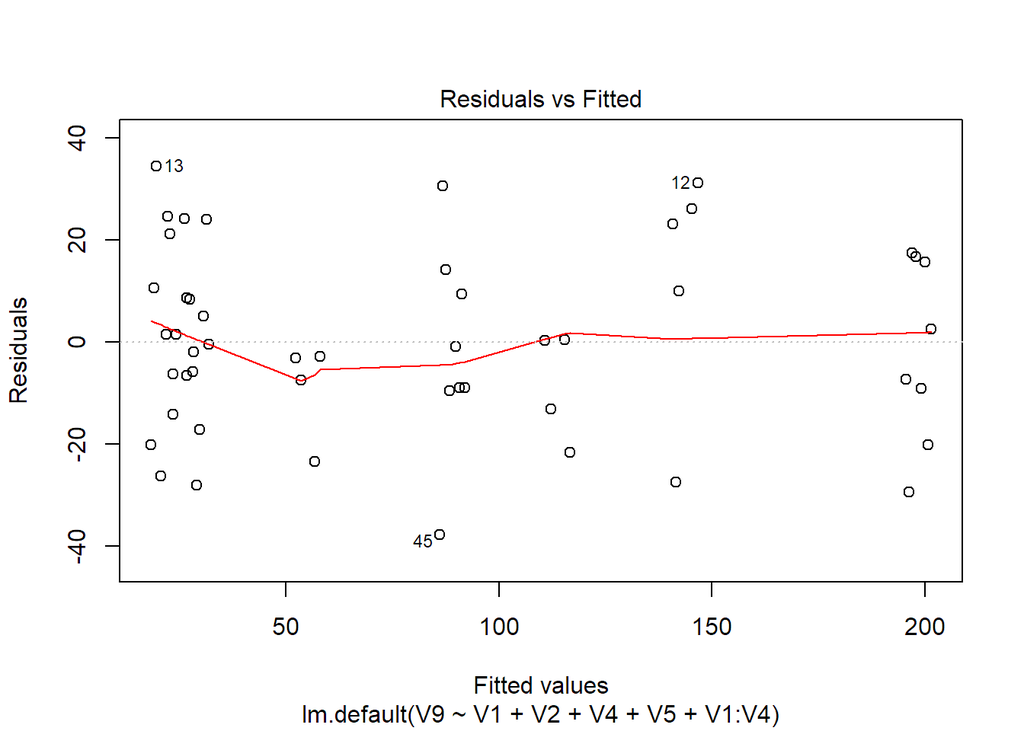

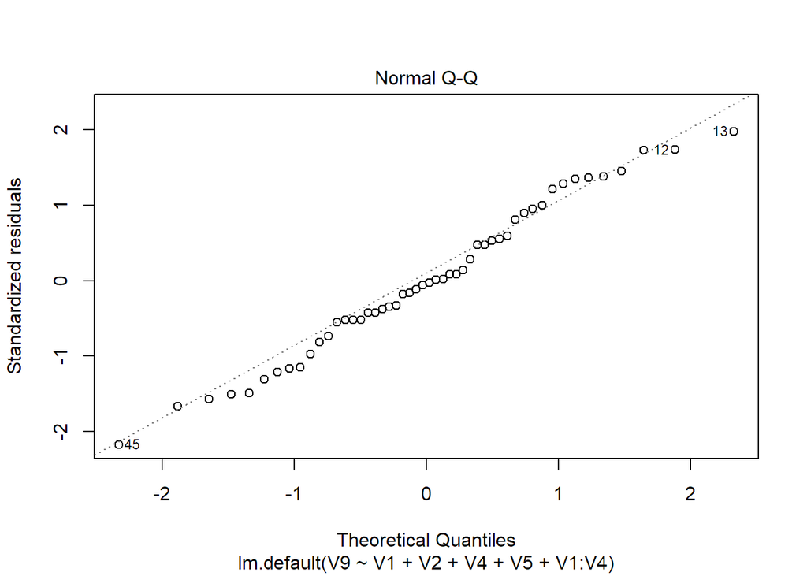

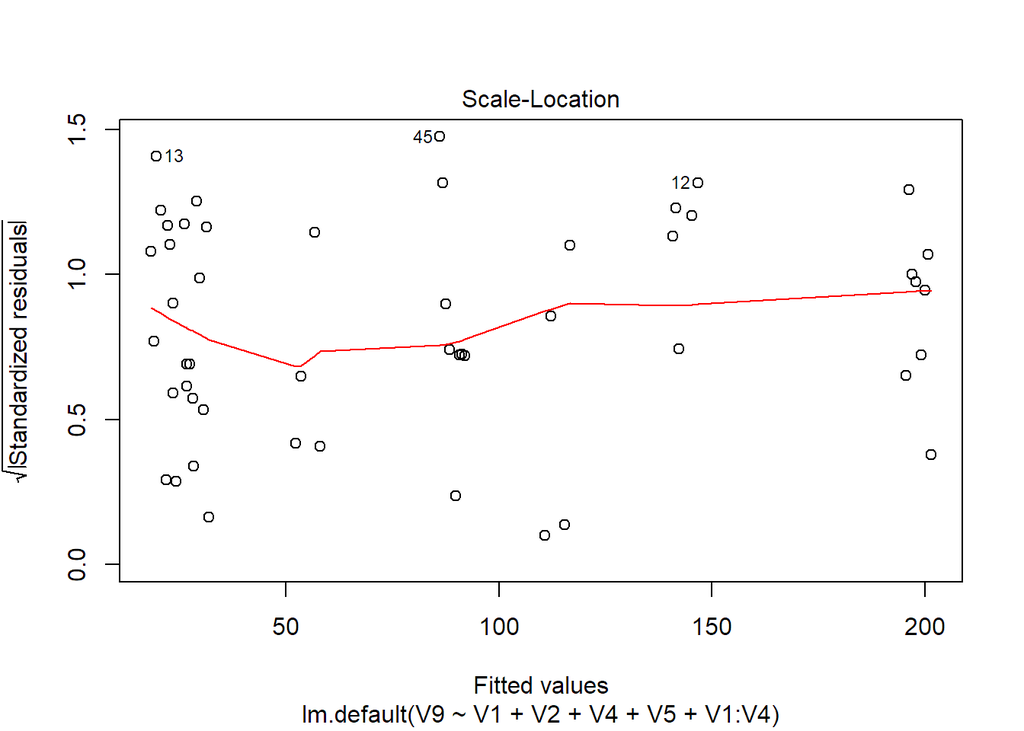

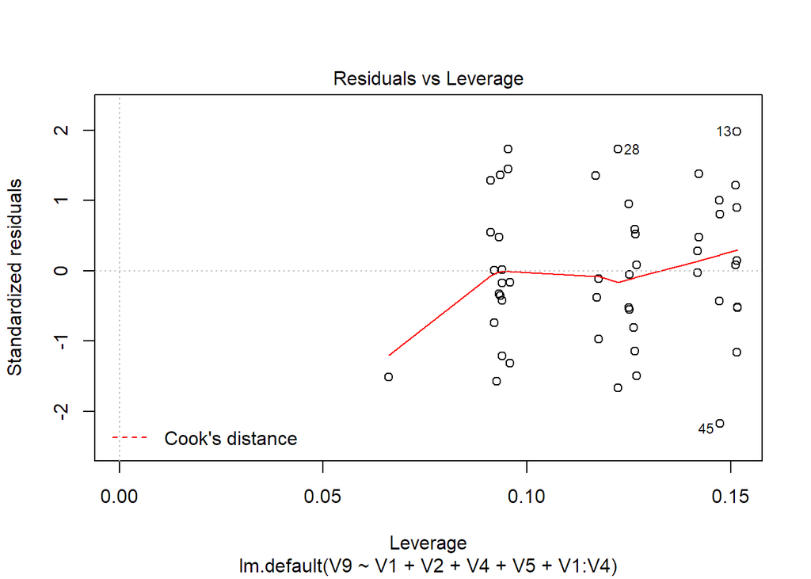

```r
plot(optLm)
```

```r
summary(optLm)
```

```
##
## Call:
## lm.default(formula = V9 ~ V1 + V2 + V4 + V5 + V1:V4, data = eg)
##
## Residuals:
##     Min      1Q  Median      3Q     Max
## -37.880  -9.557  -0.725  13.157  34.392
##
## Coefficients:
##               Estimate Std. Error t value Pr(>|t|)
## (Intercept)  1.715e+02  6.965e+01   2.463  0.01777 *
## V1          -3.677e+03  6.333e+02  -5.806 6.49e-07 ***
## V2          -9.069e-05  1.181e-04  -0.768  0.44669
## V4          -2.048e-01  6.793e-02  -3.015  0.00426 **
## V5           2.554e-02  1.127e-01   0.227  0.82181
## V1:V4        4.840e+00  6.260e-01   7.732 9.80e-10 ***
## ---
## Signif. codes:  0 '***' 0.001 '**' 0.01 '*' 0.05 '.' 0.1 ' ' 1
##
## Residual standard error: 18.86 on 44 degrees of freedom
## Multiple R-squared:  0.9283, Adjusted R-squared:  0.9201
## F-statistic: 113.9 on 5 and 44 DF,  p-value: < 2.2e-16
```

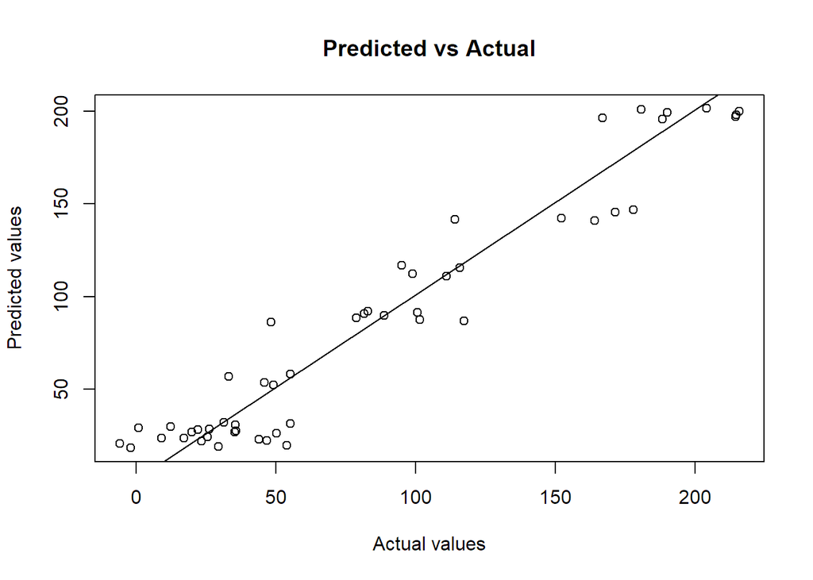

```r
newMtx <- as.matrix(cbind(mtxRes, optPred))

RMSEP <- function(y){
  sqrt((sum((y[,2]-y[,1])^2))/50)
}

RMSEP4 <- RMSEP(newMtx)

plot(newMtx, ylab = "Predicted values", xlab = "Actual values", main = "Predicted vs Actual")
abline(1,1)
```

```r
set.seed(13)
xMatrix <- gen.factorial(levels = 3, nVars = 6, varNames = c("X1","X2","X3","X4","X5","X7"))

xd <- optFederov(~X1+X2+X3+X4+X5+X7, data = xMatrix, 50)
#Cm <- mean()
X1_m <- mean(range(0.05, 0.15))
X2_m <- mean(range(100, 50000))
X3_m <- mean(range(63070, 115600))
X4_m <- mean(range(900, 1110))
X5_m <- mean(range(63.1, 116))
X6_m <- mean(range(700, 820))
X7_m <- mean(range(1120, 1680))
X8_m <- mean(range(9855, 12045))

X1 <- xd$design$X1
X2 <- xd$design$X2
X3 <- xd$design$X3
X4 <- xd$design$X4
X5 <- xd$design$X5
X7 <- xd$design$X7

X1 <- recoder(X1, '== 1: 0.15; == -1: 0.05; == 0: X1_m')
X2 <- recoder(X2, '== 1: 100; == -1: 50000; == 0: X2_m')
X3 <- recoder(X3, '== 1: 115600; == -1: 63070; == 0: X3_m')
X4 <- recoder(X4, '== 1: 900; == -1: 1110; == 0: X4_m')
X5 <- recoder(X5, '== 1: 63.1; == -1: 116; == 0: X5_m')
X7 <- recoder(X7, '== 1: 1680; == -1: 1120; == 0: X7_m')

num_rows <- nrow(xd$design)

X6 <- rep(X6_m, num_rows)
X8 <- rep(X8_m, num_rows)

mtxDopt <- matrix(c(X1,X2,X3,X4,X5,X6,X7,X8), ncol = 8)
```

```r
test_mtx <- data.frame(cbind(runif(50, 0.05, 0.15),
                      runif(50, 100, 50000),
                      runif(50, 63070, 115600),
                      runif(50, 900, 1110),
                      runif(50, 63.1, 116),
                      runif(50, 700, 820),
                      runif(50, 1120, 1680),
                      runif(50, 9855, 12045),
                     ncol = 8,
                     nrow = 50))
```

```r
mtxRes2 <- matrix(nrow = num_rows, ncol = 1)
for (i in seq(1,50)){
  mtxRes2[i,1] <- WaterFlowRateInBorehole(mtxDopt[i,])
}
mtx_opt2 <- cbind(mtxDopt, mtxRes)
eg2 <- as.data.frame(mtx_opt2)

optLm2 <- lm(V9~V1+V2+V3+V4+V5+V7+V2:V5, data = eg2)
optPred2 <- predict(optLm2)
summary(optLm2)
```

```
##
## Call:
## lm.default(formula = V9 ~ V1 + V2 + V3 + V4 + V5 + V7 + V2:V5,
##     data = eg2)
##
## Residuals:
##    Min     1Q Median     3Q    Max
## -96.70 -54.42  -7.95  46.56 118.13
##
## Coefficients:
##               Estimate Std. Error t value Pr(>|t|)
## (Intercept)  1.192e+02  1.300e+02   0.916    0.365
## V1          -1.285e+02  1.916e+02  -0.671    0.506
## V2          -4.476e-04  1.404e-03  -0.319    0.752
## V3          -2.523e-05  3.700e-04  -0.068    0.946
## V4          -6.299e-02  9.256e-02  -0.681    0.500
## V5           6.545e-01  5.204e-01   1.258    0.216
## V7          -3.163e-03  3.421e-02  -0.092    0.927
## V2:V5       -7.877e-08  1.492e-05  -0.005    0.996
##
## Residual standard error: 67.58 on 42 degrees of freedom
## Multiple R-squared:  0.1208, Adjusted R-squared:  -0.02577
## F-statistic: 0.8242 on 7 and 42 DF,  p-value: 0.5729
```

```r
anova(optLm2)
```

```
## Analysis of Variance Table
##
## Response: V9
##           Df Sum Sq Mean Sq F value  Pr(>F)
## V1         1   2391  2390.9  0.5234 0.47339
## V2         1   6463  6463.4  1.4150 0.24091
## V3         1      3     3.1  0.0007 0.97950
## V4         1   2629  2628.6  0.5755 0.45233
## V5         1  14826 14826.4  3.2459 0.07878 .
## V7         1     39    39.3  0.0086 0.92657
## V2:V5      1      0     0.1  0.0000 0.99581
## Residuals 42 191844  4567.7
## ---
## Signif. codes:  0 '***' 0.001 '**' 0.01 '*' 0.05 '.' 0.1 ' ' 1
```

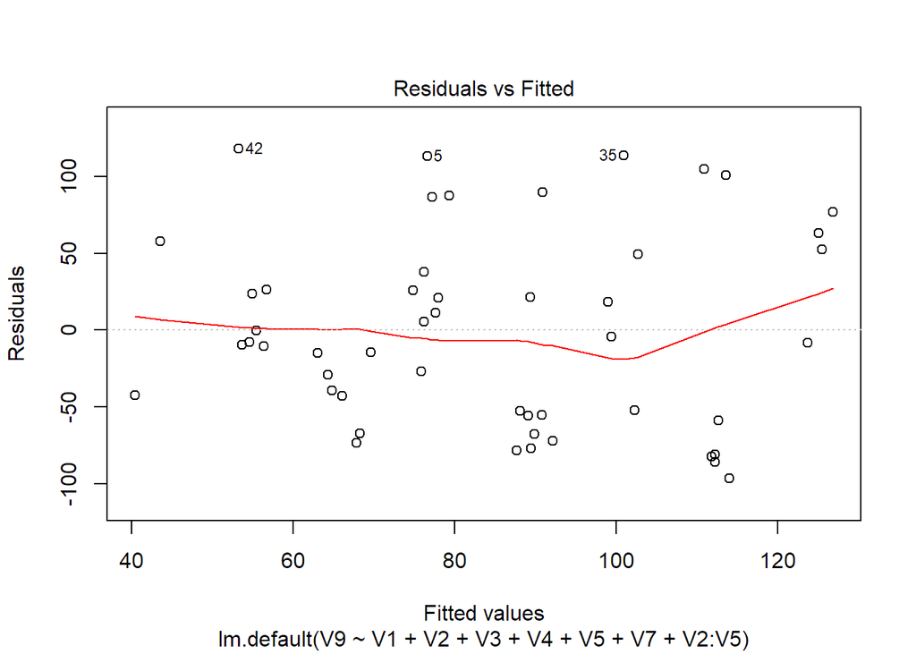

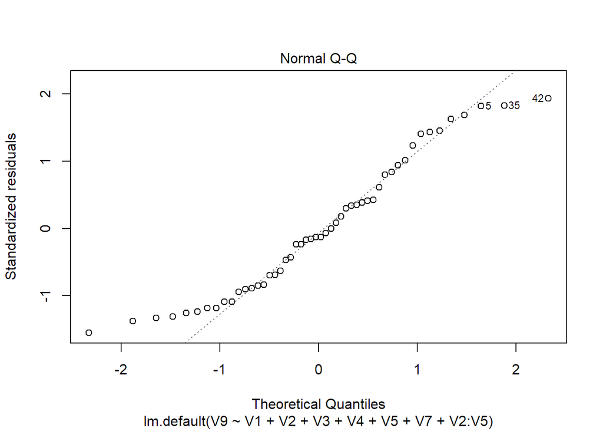

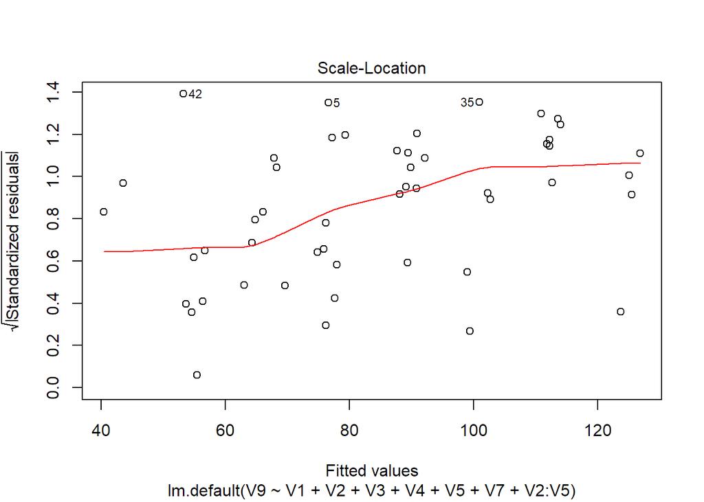

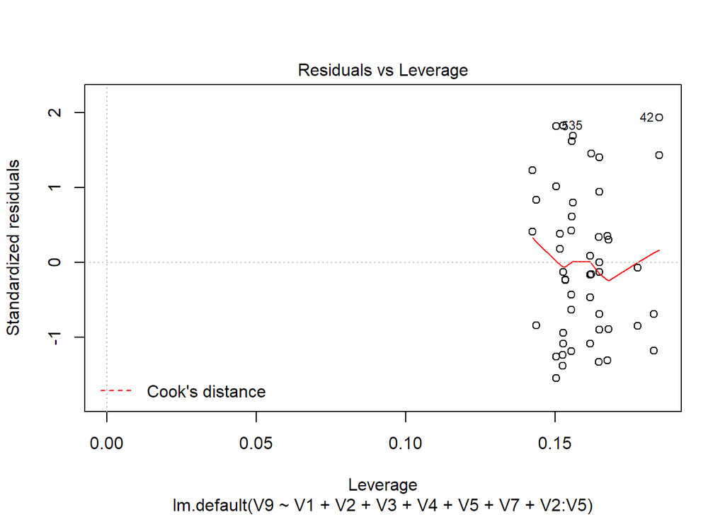

```r
plot(optLm2)
```

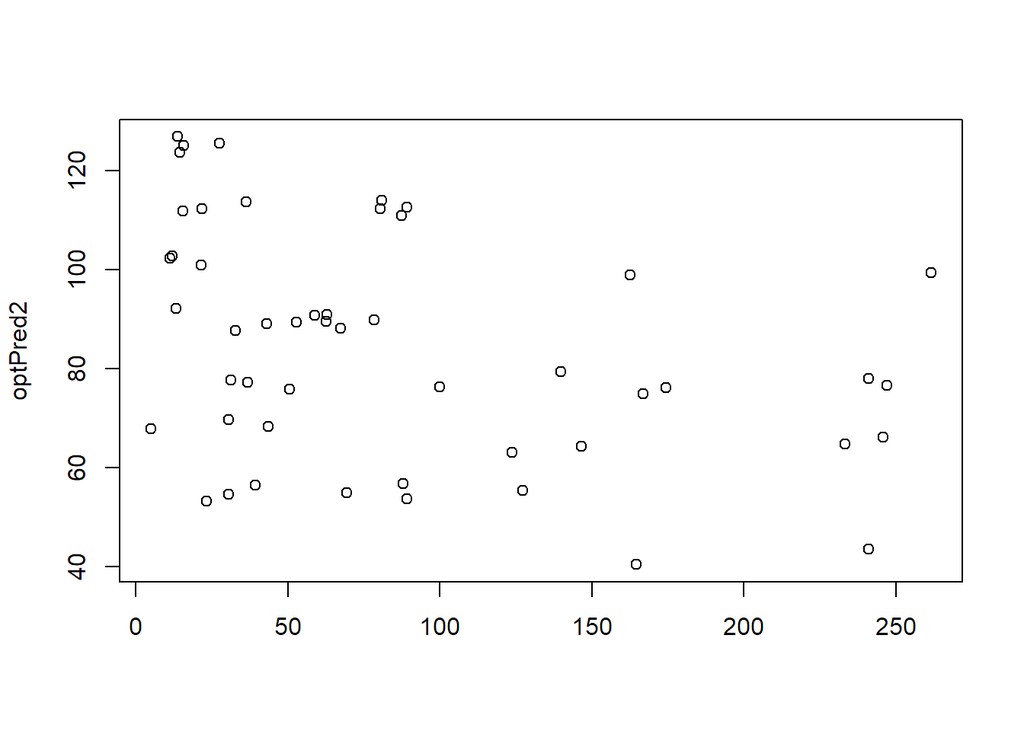

```r
newMtx2 <- as.matrix(cbind(mtxRes2, optPred2))



RMSEP <- function(y){
  sqrt((sum((y[,2]-y[,1])^2))/50)
}
plot(newMtx2)
```

```r
RMSEP(newMtx2)
```

```
## [1] 85.48002
```

```r
chisq.test(newMtx2)
```

```
##
##  Pearson's Chi-squared test
##
## data:  newMtx2
## X-squared = 1839.2, df = 49, p-value < 2.2e-16
```

# Questions

1. Use an appropriate screening design to identify the significant input variables. Clearly specify the design used, the data simulated, subsequent analysis and significant variables. [10; Maximum of one page]
2. Based on the results of screening design develop a meta model for predicting WFR using a maximum of 50 runs (simulated values of WFR). Use D-optimal design and space filling design coupled with appropriate modelling methods. Compare and contrast the performance of the two models developed. Your response should include the designs used, search criterion, simulated data, metamodel and informative graphs for comparing the performance of two metamodesl.[25: Maximum of two page]

```r
set.seed(13)
lhs <- lhsDesign(50, 4, TRUE, seed = 13)
full_lhs <- lhsDesign(50, 8, TRUE, seed = 18)

lhs_d <- lhs$design
flhs_d <- full_lhs$design
```

```r
set.seed(13)
ColX1 <- (0.05+(0.15-0.05)*lhs_d[,1])
ColX2 <- (100+(50000-100)*lhs_d[,2])
ColX4 <- (900+(1110-900)*lhs_d[,3])
ColX5 <- (63.1+(116-63.1)*lhs_d[,4])
ColX3 <- (89335)
ColX6 <- (760)
ColX7 <- (1400)
ColX8 <- (10950)

NewColX1 <- (0.05+(0.15-0.05)*flhs_d[,1])
NewColX2 <- (100+(50000-100)*flhs_d[,2])
NewColX3 <- (63070+(115600-63070)*flhs_d[,3])
NewColX4 <- (900+(1110-900)*flhs_d[,4])
NewColX5 <- (63.1+(116-63.1)*flhs_d[,5])
NewColX6 <- (700+(820-700)*flhs_d[,6])
NewColX7 <- (1120+(1680-1120)*flhs_d[,7])
NewColX8 <- (9855+(12045-9855)*flhs_d[,8])



X <- (cbind(ColX1, ColX2, ColX3, ColX4, ColX5, ColX6, ColX7, ColX8))
X1 <-(cbind(NewColX1, NewColX2, NewColX3, NewColX4, NewColX5, NewColX6, NewColX7, NewColX8))
```

```r
set.seed(13)
Xmat = X
Xnew = X1

lhd_out <- matrix(nrow = 50, ncol = 1)
for (i in seq(1,50)){
  lhd_out[i,1] <- WaterFlowRateInBorehole(X[i,])
}

y1 <- as.matrix(apply(X,1,WaterFlowRateInBorehole))
y2 <- as.matrix(apply(Xnew,1,WaterFlowRateInBorehole))

opt_lhs <- as.matrix(cbind(X,y1))
```

```r
set.seed(13)
fit1 <- buildKriging(X, y1); fit1
```

```
## ------------------------
## Forrester Kriging model.
## ------------------------
## Estimated activity parameters (theta) sorted
## from most to least important variable
## x3  x6  x7  x8  x1  x4  x5  x2
## 1.154782 1.154782 1.154782 1.154782 0.5690379 0.1112051 0.03388143 1e-04
##
## exponent(s) p:
## 2
##
## Estimated regularization constant (or nugget) lambda:
## 0.03013262
##
## Number of Likelihood evaluations during MLE:
## 456
## ------------------------
```

```r
fit2 <- buildKriging(Xnew,y2); fit2
```

```
## ------------------------
## Forrester Kriging model.
## ------------------------
## Estimated activity parameters (theta) sorted
## from most to least important variable
## x2  x1  x4  x6  x3  x5  x7  x8
## 3.205895 1.993931 0.8057927 0.3113731 1e-04 1e-04 1e-04 1e-04
##
## exponent(s) p:
## 2
##
## Estimated regularization constant (or nugget) lambda:
## 0.1308744
##
## Number of Likelihood evaluations during MLE:
## 988
## ------------------------
```

```r
hehe <- predict(fit1, X); hehe
```

```
## $y
##  [1]  32.36670 115.44088 115.83591  73.11907  20.45049  86.44894  57.99810
##  [8] 117.25566  46.06947  97.34660  46.13283  51.97466  90.00144  20.01293
## [15] 164.35753  17.43804 135.91948 142.85423  91.70311  30.68252  18.83472
## [22]  16.29397  75.36387  49.64872 119.43834 126.58830  96.53377  25.92346
## [29]  36.45226  48.22098  32.20930  18.97042  39.17622 111.04522 139.72111
## [36] 157.48617  46.97831 160.68371 127.84670  63.00136 129.63563 103.69907
## [43]  46.65354  98.70133  63.96433  67.73756  22.44062  23.24916  55.69059
## [50]  50.68885
```

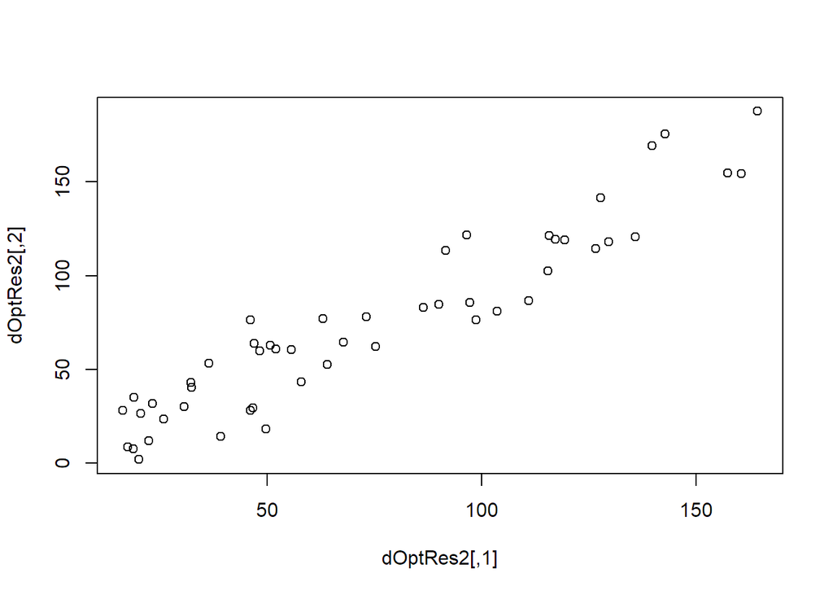

```r
haha <- predict(fit2, Xnew)

dOptRes <- as.matrix(cbind(haha$y,y1))

dOptRes2 <- as.matrix(cbind(hehe$y,y1))
plot(dOptRes2)
```

```r
plot(dOptRes)
RMSEP <- function(y){
  sqrt((sum((y[,2]-y[,1])^2))/50)
}
Rsqr <- function(val){
  y_m <- mean(val[,2])
  sum(val[,1]-y_m)^2/sum(val[,2]-val[,1])^2
}

Rsqr(dOptRes2)
```

```
## [1] 1.001501
```

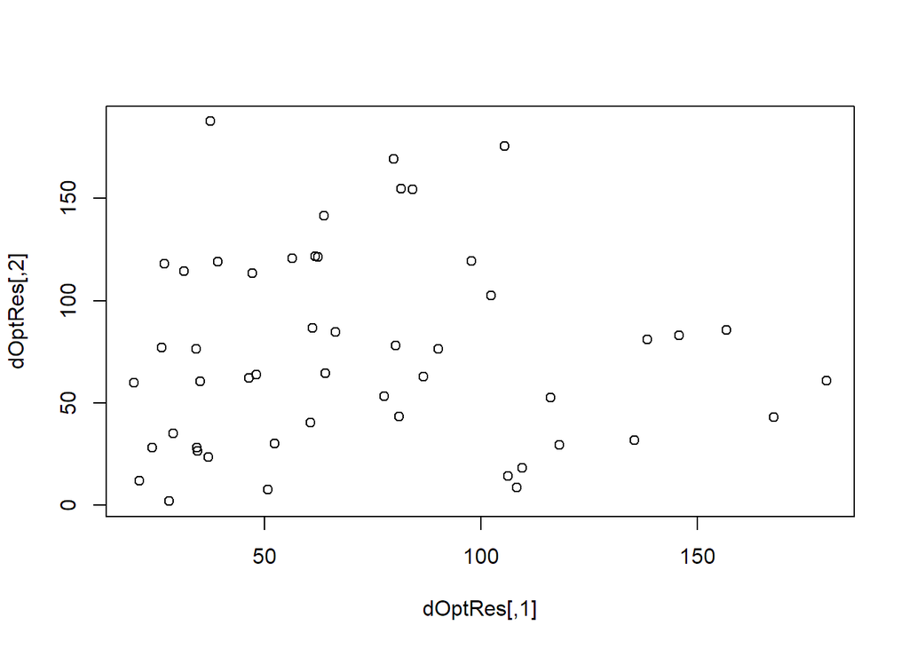

```r
plot(dOptRes)
```

```r
RMSEP(dOptRes2)
```

```
## [1] 15.77823
```

```r
RMSEP(dOptRes)
```

```
## [1] 62.48371
```

3. Using best meta models in 2, and assuming that each range of input variable provided is the 5th, and 95th percentile respectively, generate the distribution of WFR. Present informative graphs and specify the features of the distribution. [10: Maximum of one page]

```r
percentile <- qnorm(0.95)
X1_sd <- (X1_m-0.05)/percentile
X2_sd <- (X2_m-100)/percentile
X4_sd <- (X4_m-900)/percentile
X5_sd <- (X5_m-63.1)/percentile

distMtx <- lhsDesign(200, 4, TRUE, seed = 63)
matrice <- distMtx$design

new_Val1 <- abs(qnorm(matrice[,1], X1_m, X1_sd))
new_Val2 <- abs(qnorm(matrice[,1], X2_m, X2_sd))
new_Val4 <- abs(qnorm(matrice[,1], X4_m, X4_sd))
new_Val5 <- abs(qnorm(matrice[,1], X5_m, X5_sd))

finalMtx <- matrix(cbind(new_Val1, new_Val2, X3_m, new_Val4, new_Val5, X6_m, X7_m, X8_m), ncol = 8)

Pt3_out <- matrix(nrow = 200, ncol = 1)
for (i in seq(1,nrow(Pt3_out))){
  Pt3_out[i,1] <- WaterFlowRateInBorehole(finalMtx[i,])
}

finalDf <- as.data.frame(cbind(finalMtx, Pt3_out))
is.factor(finalDf$V4)
```

```
## [1] FALSE
```

```r
finalLm <- lm(V9~V1+V2+V4+V5+V1:V4, data=  finalDf)

summary(finalLm)
```

```
##
## Call:
## lm.default(formula = V9 ~ V1 + V2 + V4 + V5 + V1:V4, data = finalDf)
##
## Residuals:
##     Min      1Q  Median      3Q     Max
## -47.024 -14.510   0.061  14.304  48.049
##
## Coefficients: (2 not defined because of singularities)
##               Estimate Std. Error t value Pr(>|t|)
## (Intercept)  5.820e+01  1.112e+01   5.232 4.29e-07 ***
## V1          -8.585e+03  6.749e+02 -12.720  < 2e-16 ***
## V2          -1.351e-03  5.438e-04  -2.485   0.0138 *
## V4                  NA         NA      NA       NA
## V5                  NA         NA      NA       NA
## V1:V4        8.996e+00  6.602e-01  13.627  < 2e-16 ***
## ---
## Signif. codes:  0 '***' 0.001 '**' 0.01 '*' 0.05 '.' 0.1 ' ' 1
##
## Residual standard error: 19.88 on 196 degrees of freedom
## Multiple R-squared:  0.896,  Adjusted R-squared:  0.8945
## F-statistic: 563.2 on 3 and 196 DF,  p-value: < 2.2e-16
```

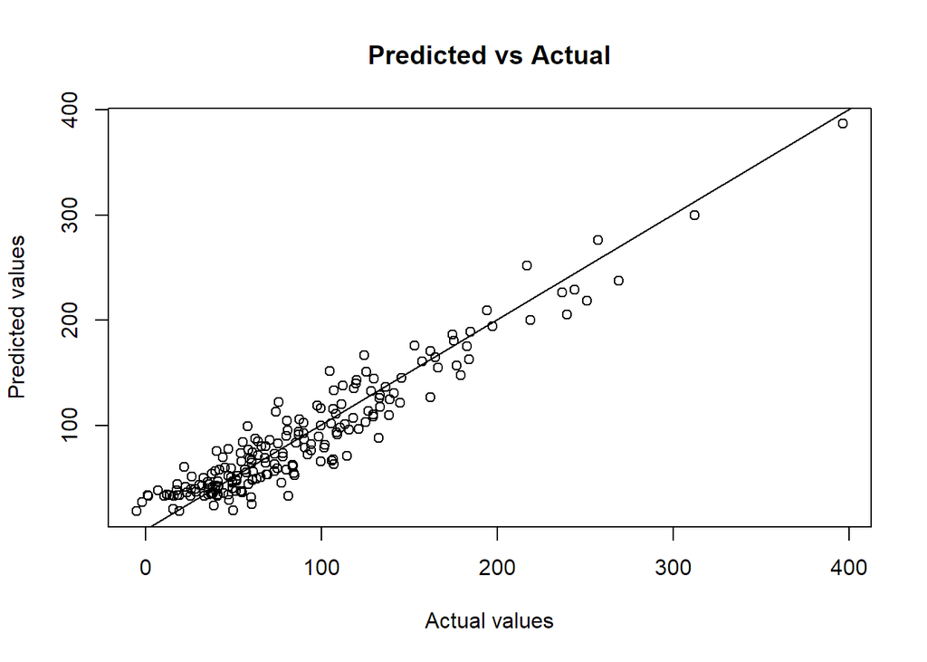

```r
final_Pred <- predict(finalLm)
final_final <- matrix(c(Pt3_out, final_Pred), ncol=2)

plot(final_final, ylab = "Predicted values", xlab = "Actual values", main = "Predicted vs Actual")
abline(1,1)
```

```r
RMSEP(final_final)
```

```
## [1] 39.35845
```

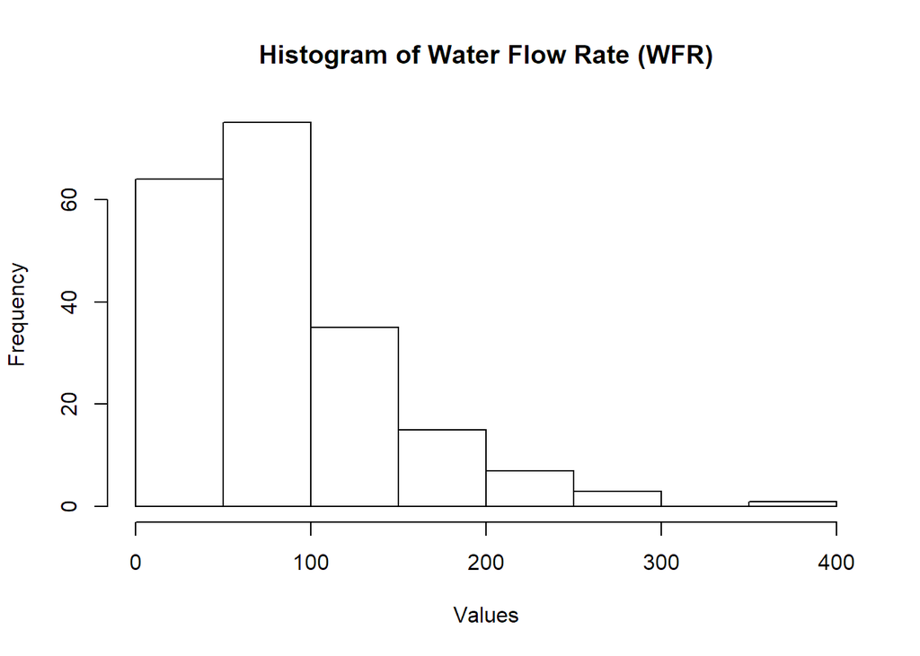

```r
hist(final_Pred, main = "Histogram of Water Flow Rate (WFR)", xlab = "Values")
```